# The relationship between a translational cognitive measure of negative bias and self-reported psychiatric symptoms in a large online sample

# Background

This study builds on prior work developing a measure of negative affective bias as indexed by proportion of mid tones interpreted as high reward (‘p(mid as high)’) in A) a rat pharmacological model of mood and anxiety disorders (Hales et al., 2016) and B) humans with mood and anxiety disorders relative to healthy controls (Aylward et al., 2019).

#### Next steps

This prior work suggests that this cognitive measure is sensitive to pathological symptoms. We have three objectives for the present study. Firstly we wanted to explore and remove sources of between-subject bias within the task so as to maximise our chances of measuring individual differences in task performance. Secondly, we wanted to explore factors which contribute to individual differences in task performance in a large cross-sectional sample. Specifically, we are interested in which specific psychiatric-relevant symptoms/traits contribute to task performance. Finally, once we identify relevant traits, can we re-capitulate the effect of clinical screening in a large unscreened online sample?

# 1: Piloting to explore sources of between-subject bias

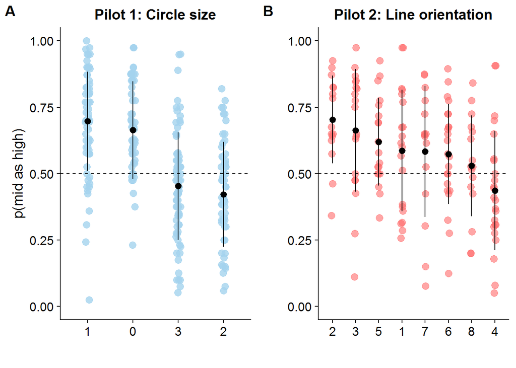

```
##              Df Sum Sq Mean Sq F value Pr(>F)
## group         3  3.964  1.3215   35.28 <2e-16 ***
## Residuals   260  9.739  0.0375
## ---
## Signif. codes:  0 '***' 0.001 '**' 0.01 '*' 0.05 '.' 0.1 ' ' 1
```

```
##          eta.sq eta.sq.part
## group 0.2893019   0.2893019
```

```
##              Df Sum Sq Mean Sq F value  Pr(>F)
## group         7  0.929 0.13267   3.077 0.00475 **
## Residuals   143  6.165 0.04311
## ---
## Signif. codes:  0 '***' 0.001 '**' 0.01 '*' 0.05 '.' 0.1 ' ' 1
```

```
##          eta.sq eta.sq.part
## group 0.1309089   0.1309089
```

```
##   Tukey multiple comparisons of means
##     95% family-wise confidence level
##
## Fit: aov(formula = Pmid ~ group, data = pilot1cb)
##
## $group
##            diff         lwr        upr     p adj
## 1-0  0.03319086 -0.05510565  0.1214874 0.7655217
## 2-0 -0.24185068 -0.33400241 -0.1496990 0.0000000
## 3-0 -0.21067170 -0.29843425 -0.1229092 0.0000000
## 2-1 -0.27504154 -0.36251921 -0.1875639 0.0000000
## 3-1 -0.24386256 -0.32670376 -0.1610213 0.0000000
## 3-2  0.03117898 -0.05575969  0.1181177 0.7902342
```

```
##   Tukey multiple comparisons of means
##     95% family-wise confidence level
##
## Fit: aov(formula = Pmid ~ group, data = pilot2cb)
##
## $group
##             diff         lwr         upr     p adj
## 2-1  0.116847213 -0.10133355  0.33502797 0.7205659
## 3-1  0.076216643 -0.12842007  0.28085336 0.9453463
## 4-1 -0.150419157 -0.34381573  0.04297742 0.2529895
## 5-1  0.033392280 -0.17124444  0.23802900 0.9996371
## 6-1 -0.012709407 -0.20800766  0.18258885 0.9999993
## 7-1 -0.002821500 -0.22100226  0.21535926 1.0000000
## 8-1 -0.057236747 -0.27148600  0.15701251 0.9916272
## 3-2 -0.040630570 -0.26125829  0.17999715 0.9991964
## 4-2 -0.267266370 -0.47751061 -0.05702213 0.0034682
## 5-2 -0.083454933 -0.30408266  0.13717279 0.9407917
## 6-2 -0.129556620 -0.34155147  0.08243823 0.5668175
## 7-2 -0.119668713 -0.35291376  0.11357633 0.7624254
## 8-2 -0.174083960 -0.40365562  0.05548770 0.2834033
## 4-3 -0.226635800 -0.42278876 -0.03048284 0.0117584
## 5-3 -0.042824363 -0.25006802  0.16441930 0.9983082
## 6-3 -0.088926050 -0.28695422  0.10910212 0.8642912
## 7-3 -0.079038143 -0.29966587  0.14158958 0.9554490
## 8-3 -0.133453390 -0.35019400  0.08328722 0.5571819
## 5-4  0.183811438 -0.01234152  0.37996440 0.0838114
## 6-4  0.137709750 -0.04868018  0.32409968 0.3158952
## 7-4  0.147597657 -0.06264658  0.35784190 0.3824994
## 8-4  0.093182411 -0.11297903  0.29934385 0.8602737
## 6-5 -0.046101687 -0.24412986  0.15192649 0.9964027
## 7-5 -0.036213780 -0.25684150  0.18441394 0.9996228
## 8-5 -0.090629027 -0.30736963  0.12611158 0.9025639
## 7-6  0.009887907 -0.20210694  0.22188275 0.9999999
## 8-6 -0.044527340 -0.25247376  0.16341908 0.9978766
## 8-7 -0.054415247 -0.28398691  0.17515642 0.9959758
```

#### Interpretation

Both tasks demonstrate clear sources of between-subject bias. In short, individuals demonstrated ‘higher’ bias when large (or vertical) stimuli were paired with large rewards on the right hand side. These reflect pre-potent biases (e.g. bigger things usually cost more and in latinate languages we read from left to right etc.). Smaller biases were observed when the stimulus-response-outcome contingencies were incongruent with these pre-potent biases. These biases add to the noise in within-subject or case-control designs, but effects can still be observed over and above these effects. Unfortunately if we care about within-subject differences in a cross-sectional design we have to remove this. We decided to restrict further testing to the intermediate bias scores on pilot 2 (counterbalancing 1 and 7). Thus we would need to control for counterbalancing but would only have two groups (rather than 8). Of note, we chose pilot 2 design rather than pilot 1 because a circle has both area and diameter that a participant may attend to, whereas there is only one interpretation of line orientation.

# 2: Exploring contributors to bias in cross-sectional data

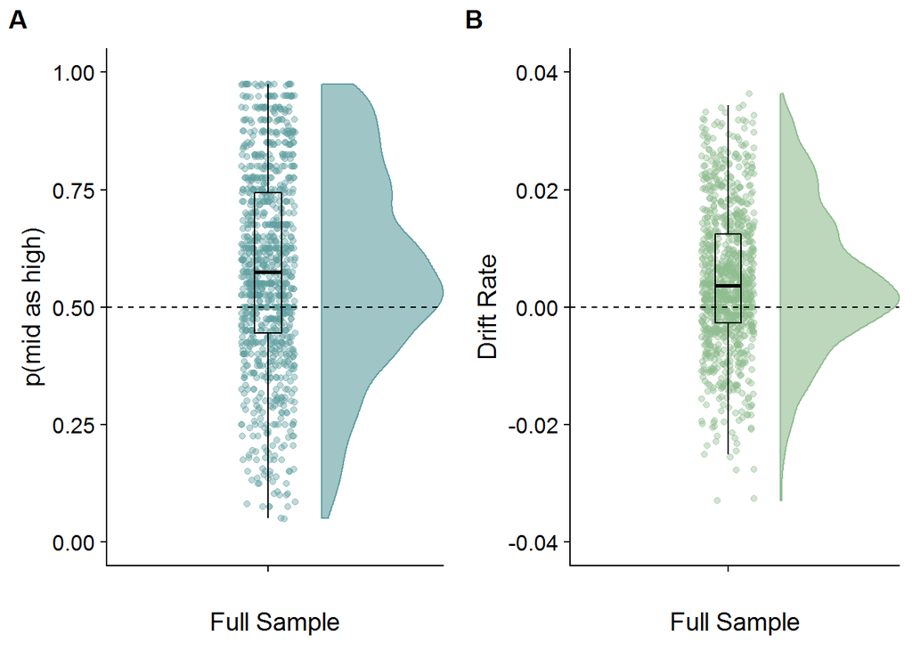

```
##
##  One Sample t-test
##
## data:  combineditemdata$propmedhigh
## t = 12.089, df = 993, p-value < 2.2e-16
## alternative hypothesis: true mean is not equal to 0.5
## 95 percent confidence interval:
##  0.5671525 0.5931778
## sample estimates:
## mean of x
## 0.5801652
```

```
##
##  One Sample t-test
##
## data:  combineditemdata$driftrate
## t = 12.113, df = 993, p-value < 2.2e-16
## alternative hypothesis: true mean is not equal to 0
## 95 percent confidence interval:
##  0.003843921 0.005330160
## sample estimates:
##  mean of x
## 0.00458704
```

|  | mean | std | lower range | upper range |
| --- | --- | --- | --- | --- |
| Age | 34 | 10 | 18 | 76 |
| Ravens | 4 | 3 | 0 | 12 |
| OCIR | 42 | 18 | 18 | 90 |
| SZ | 16 | 9 | 0 | 51 |
| BDI | 15 | 12 | 0 | 56 |
| STAI | 45 | 12 | 20 | 78 |

```
## Split half reliabilities
## Call: splitHalf(r = dataforsh, raw = T, brute = FALSE, n.sample = 1e+05,
##     covar = FALSE, check.keys = TRUE, key = NULL, ci = 0.05,
##     use = "pairwise")
##
## Maximum split half reliability (lambda 4) =  0.94
## Guttman lambda 6                          =  0.92
## Average split half reliability            =  0.91
## Guttman lambda 3 (alpha)                  =  0.91
## Minimum split half reliability  (beta)    =  0.85
## Average interitem r =  0.21  with median =  0.21
##                                              2.5% 50% 97.5%
##  Quantiles of split half reliability      =  0.9 0.92 0.93
```

### Simple Linear Regression of measures

To explore the impact of trait/demographic measures on task performance we next ran a linear regression (using Robust ML estimator for consistency with SEM below) to predict p(mid as high)(‘propmedhigh’ variable). The variables we included are:

- Spreadsheet (categorical): represents the counterbalancing condition
- Ravens (continuous): IQ measure (visual matrices)
- Age (continuous): years old
- BDI (continuous): Beck depression inventory (suicide question removed)
- STAI2 (continuous): Spielberger Trait Anxiety
- OCIR (continuous): Obsessive-Compulsive Inventory (Revised)
- SZ (continuous): Schizotypal short scale
- September1.April2 (categorical): Two batches of data
- TakeDrugs (categorical): Current use of psychoactive compounds
- GenderMF (categorical): Self-reported gender
- CurrentMH (categorical): Are you suffering from current mental health problems?

```r
NegBiasmodel.1 <- 'propmedhigh ~ GenderMF + Age + Ravens + spreadsheet +BDI + STAI2 + SZ + OCIR'
NegBiasmodel.2 <- 'driftrate ~ GenderMF + Age + Ravens + spreadsheet +BDI + STAI2 + SZ + OCIR'


fit1 <- sem(NegBiasmodel.1, data=combineditemdata, meanstructure=TRUE,  estimator = "MLR")
fit2 <- sem(NegBiasmodel.2, data=combineditemdata, meanstructure=TRUE,  estimator = "MLR")


summary(fit1, standardized=TRUE, rsquare=T, fit.measures=F)
```

```
## lavaan 0.6-3 ended normally after 59 iterations
##
##   Optimization method                           NLMINB
##   Number of free parameters                         10
##
##                                                   Used       Total
##   Number of observations                           990        1066
##
##   Estimator                                         ML      Robust
##   Model Fit Test Statistic                       0.000       0.000
##   Degrees of freedom                                 0           0
##   Minimum Function Value               0.0000000000000
##   Scaling correction factor                                     NA
##     for the Yuan-Bentler correction (Mplus variant)
##
## Parameter Estimates:
##
##   Information                                 Observed
##   Observed information based on                Hessian
##   Standard Errors                   Robust.huber.white
##
## Regressions:
##                    Estimate  Std.Err  z-value  P(>|z|)   Std.lv  Std.all
##   propmedhigh ~
##     GenderMF         -0.005    0.013   -0.390    0.697   -0.005   -0.012
##     Age              -0.002    0.001   -3.822    0.000   -0.002   -0.120
##     Ravens            0.010    0.002    4.323    0.000    0.010    0.144
##     spreadsheet       0.006    0.002    2.744    0.006    0.006    0.085
##     BDI              -0.002    0.001   -2.373    0.018   -0.002   -0.121
##     STAI2             0.001    0.001    0.789    0.430    0.001    0.037
##     SZ               -0.001    0.001   -1.145    0.252   -0.001   -0.056
##     OCIR              0.000    0.001    0.087    0.931    0.000    0.004
##
## Intercepts:
##                    Estimate  Std.Err  z-value  P(>|z|)   Std.lv  Std.all
##    .propmedhigh       0.663    0.042   15.791    0.000    0.663    3.166
##
## Variances:
##                    Estimate  Std.Err  z-value  P(>|z|)   Std.lv  Std.all
##    .propmedhigh       0.041    0.002   24.796    0.000    0.041    0.943
##
## R-Square:
##                    Estimate
##     propmedhigh       0.057
```

```r
summary(fit2, standardized=TRUE, rsquare=T, fit.measures=F)
```

```
## lavaan 0.6-3 ended normally after 124 iterations
##
##   Optimization method                           NLMINB
##   Number of free parameters                         10
##
##                                                   Used       Total
##   Number of observations                           990        1066
##
##   Estimator                                         ML      Robust
##   Model Fit Test Statistic                       0.000       0.000
##   Degrees of freedom                                 0           0
##   Scaling correction factor                                     NA
##     for the Yuan-Bentler correction (Mplus variant)
##
## Parameter Estimates:
##
##   Information                                 Observed
##   Observed information based on                Hessian
##   Standard Errors                   Robust.huber.white
##
## Regressions:
##                    Estimate  Std.Err  z-value  P(>|z|)   Std.lv  Std.all
##   driftrate ~
##     GenderMF         -0.000    0.001   -0.421    0.674   -0.000   -0.013
##     Age              -0.000    0.000   -3.611    0.000   -0.000   -0.113
##     Ravens            0.001    0.000    4.348    0.000    0.001    0.146
##     spreadsheet       0.000    0.000    2.766    0.006    0.000    0.086
##     BDI              -0.000    0.000   -2.533    0.011   -0.000   -0.127
##     STAI2             0.000    0.000    0.876    0.381    0.000    0.040
##     SZ               -0.000    0.000   -1.355    0.175   -0.000   -0.066
##     OCIR              0.000    0.000    0.392    0.695    0.000    0.018
##
## Intercepts:
##                    Estimate  Std.Err  z-value  P(>|z|)   Std.lv  Std.all
##    .driftrate         0.009    0.002    3.707    0.000    0.009    0.740
##
## Variances:
##                    Estimate  Std.Err  z-value  P(>|z|)   Std.lv  Std.all
##    .driftrate         0.000    0.000   21.371    0.000    0.000    0.943
##
## R-Square:
##                    Estimate
##     driftrate         0.057
```

#### Interpretation

Affective bias and drift rate are both significantly influenced by IQ, Age, BDI and counterbalancing only. Thus of mental health relevant symptoms, task performance appears to be more driven by depresson than anxiety, OCD, or psychosis related traits.

### Correlation between task performance and depression symptoms

To illustrate the effect of depression in the regression we plot the correlation between BDI and pmidhigh/drift rate in raw scores. Consistent with our prior work, increased depression is associated with reduced p(mid as high)(i.e. increased negative bias).

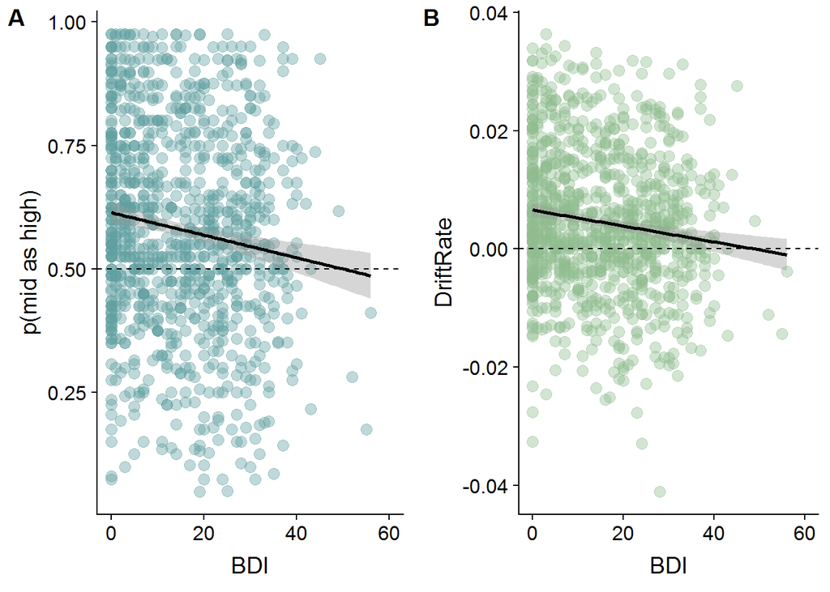

```
##
##  Pearson's product-moment correlation
##
## data:  combineditemdata$BDI and combineditemdata$propmedhigh
## t = -4.1239, df = 992, p-value = 4.036e-05
## alternative hypothesis: true correlation is not equal to 0
## 95 percent confidence interval:
##  -0.19046936 -0.06819752
## sample estimates:
##       cor
## -0.129827
```

```
##
##  Pearson's product-moment correlation
##
## data:  combineditemdata$BDI and combineditemdata$driftrate
## t = -4.2639, df = 992, p-value = 2.2e-05
## alternative hypothesis: true correlation is not equal to 0
## 95 percent confidence interval:
##  -0.19471183 -0.07258157
## sample estimates:
##        cor
## -0.1341561
```

### Exploring latent variable structure of the Questionnaires

The linear regression assumes that the summary scores of the questionnaires represent discrete categories. However, it is possible that effects are driven by a generic ‘mental ill health’ factor (sometimes referred to as a P factor model). Or, some questionnaires (e.g. BDI and trait anxiety, which are usually highly correlated) actually meausure a single latent ‘negative affect’ factor. To test for these possibilities we explore four confirmatory factor analyses feeding the individual items from the questionnaires into 1-4 latent factors. The 4 latent factor CFA represents the items feeding into the original questionnaires.

```r
###Testing different measurement models

pFactor1<-'#specifying measurement model

P   =~ BDI_Appetite_quantised   +
       BDI_Attractive_quantised +
       BDI_Blame_quantised  +
       BDI_Cry_quantised    +
       BDI_Decisions_quantised  +
       BDI_Disappointment_quantised +
       BDI_Failure_quantised    +
       BDI_Future_quantised +
       BDI_Guilty_quantised +
       BDI_Health_quantised +
       BDI_Interest_In_People_quantised +
       BDI_Irritated_quantised  +
       BDI_Libido_quantised +
       BDI_Punished_quantised   +
       BDI_Sad_quantised +
       BDI_Satisfaction_quantised   +
       BDI_Sleep_quantised  +
       BDI_Tired_quantised  +
       BDI_weight_quantised +
       BDI_Work_quantised   +
        STAI2_Calm_quantised +
        STAI2_Content_quantised +
        STAI2_Desicions_quantised +
        STAI2_Difficulties_quantised +
        STAI2_DisappointmentsSelf_quantised +
        STAI2_Failure_quantised +
        STAI2_Happy_quantised +
        STAI2_HappyOthers_quantised +
        STAI2_Inadequate_quantised +
        STAI2_Nervous_quantised +
        STAI2_Pleasant_quantised +
        STAI2_Rested_quantised +
        STAI2_SatisfiedSelf_quantised +
        STAI2_Secure_quantised +
        STAI2_SelfConfidence_quantised +
        STAI2_Steady_quantised +
        STAI2_Tension_quantised +
        STAI2_Thoughts_quantised +
        STAI2_UnimportantThought_quantised +
        STAI2_Worry_quantised +
       OCIR_14_quantised    +
       OCIR_15_quantised    +
       OCIR_16_quantised    +
       OCIR_17_quantised    +
       OCIR_18_quantised    +
       OCIR_2_quantised +
       OCIR_3_quantised +
       OCIR_4_quantised +
       OCIR_5_quantised +
       OCIR_6_quantised +
       OCIR_7_quantised +
       OCIR_8_quantised +
       OCIR_9_quantised +
       OCIR_1_quantised +
       OCIR_10_quantised    +
       OCIR_11_quantised    +
       OCIR_12_quantised    +
       OCIR_13_quantised  +
      SZ_1_quantised    +
      SZ_10_quantised   +
      SZ_11_quantised +
      SZ_12_quantised +
      SZ_13_quantised +
      SZ_14_quantised +
      SZ_15_quantised +
      SZ_16_quantised +
      SZ_17_quantised +
      SZ_18_quantised +
      SZ_19_quantised +
      SZ_2_quantised +
      SZ_20_quantised +
      SZ_21_quantised +
      SZ_22_quantised +
      SZ_23_quantised +
      SZ_24_quantised +
      SZ_25_quantised +
      SZ_26_quantised +
      SZ_27_quantised +
      SZ_28_quantised +
      SZ_29_quantised +
      SZ_3_quantised +
      SZ_30_quantised +
      SZ_31_quantised +
      SZ_32_quantised +
      SZ_33_quantised +
      SZ_34_quantised +
      SZ_35_quantised +
      SZ_36_quantised +
      SZ_37_quantised +
      SZ_38_quantised +
      SZ_39_quantised +
      SZ_4_quantised +
      SZ_40_quantised +
      SZ_41_quantised +
      SZ_42_quantised +
      SZ_5_quantised +
      SZ_6_quantised +
      SZ_7_quantised +
      SZ_8_quantised +
      SZ_9_quantised
'

BiFactor2<-'#specifying measurement model

ANXDEP =~ BDI_Appetite_quantised    +
       BDI_Attractive_quantised +
       BDI_Blame_quantised  +
       BDI_Cry_quantised    +
       BDI_Decisions_quantised  +
       BDI_Disappointment_quantised +
       BDI_Failure_quantised    +
       BDI_Future_quantised +
       BDI_Guilty_quantised +
       BDI_Health_quantised +
       BDI_Interest_In_People_quantised +
       BDI_Irritated_quantised  +
       BDI_Libido_quantised +
       BDI_Punished_quantised   +
       BDI_Sad_quantised +
       BDI_Satisfaction_quantised   +
       BDI_Sleep_quantised  +
       BDI_Tired_quantised  +
       BDI_weight_quantised +
       BDI_Work_quantised   +
        STAI2_Calm_quantised +
        STAI2_Content_quantised +
        STAI2_Desicions_quantised +
        STAI2_Difficulties_quantised +
        STAI2_DisappointmentsSelf_quantised +
        STAI2_Failure_quantised +
        STAI2_Happy_quantised +
        STAI2_HappyOthers_quantised +
        STAI2_Inadequate_quantised +
        STAI2_Nervous_quantised +
        STAI2_Pleasant_quantised +
        STAI2_Rested_quantised +
        STAI2_SatisfiedSelf_quantised +
        STAI2_Secure_quantised +
        STAI2_SelfConfidence_quantised +
        STAI2_Steady_quantised +
        STAI2_Tension_quantised +
        STAI2_Thoughts_quantised +
        STAI2_UnimportantThought_quantised +
        STAI2_Worry_quantised

OTH =~ OCIR_14_quantised    +
       OCIR_15_quantised    +
       OCIR_16_quantised    +
       OCIR_17_quantised    +
       OCIR_18_quantised    +
       OCIR_2_quantised +
       OCIR_3_quantised +
       OCIR_4_quantised +
       OCIR_5_quantised +
       OCIR_6_quantised +
       OCIR_7_quantised +
       OCIR_8_quantised +
       OCIR_9_quantised +
       OCIR_1_quantised +
       OCIR_10_quantised    +
       OCIR_11_quantised    +
       OCIR_12_quantised    +
       OCIR_13_quantised  +
      SZ_1_quantised    +
      SZ_10_quantised   +
      SZ_11_quantised +
      SZ_12_quantised +
      SZ_13_quantised +
      SZ_14_quantised +
      SZ_15_quantised +
      SZ_16_quantised +
      SZ_17_quantised +
      SZ_18_quantised +
      SZ_19_quantised +
      SZ_2_quantised +
      SZ_20_quantised +
      SZ_21_quantised +
      SZ_22_quantised +
      SZ_23_quantised +
      SZ_24_quantised +
      SZ_25_quantised +
      SZ_26_quantised +
      SZ_27_quantised +
      SZ_28_quantised +
      SZ_29_quantised +
      SZ_3_quantised +
      SZ_30_quantised +
      SZ_31_quantised +
      SZ_32_quantised +
      SZ_33_quantised +
      SZ_34_quantised +
      SZ_35_quantised +
      SZ_36_quantised +
      SZ_37_quantised +
      SZ_38_quantised +
      SZ_39_quantised +
      SZ_4_quantised +
      SZ_40_quantised +
      SZ_41_quantised +
      SZ_42_quantised +
      SZ_5_quantised +
      SZ_6_quantised +
      SZ_7_quantised +
      SZ_8_quantised +
      SZ_9_quantised
'

TriFactor3<-'#specifying measurement model

ANXDEP =~ BDI_Appetite_quantised    +
       BDI_Attractive_quantised +
       BDI_Blame_quantised  +
       BDI_Cry_quantised    +
       BDI_Decisions_quantised  +
       BDI_Disappointment_quantised +
       BDI_Failure_quantised    +
       BDI_Future_quantised +
       BDI_Guilty_quantised +
       BDI_Health_quantised +
       BDI_Interest_In_People_quantised +
       BDI_Irritated_quantised  +
       BDI_Libido_quantised +
       BDI_Punished_quantised   +
       BDI_Sad_quantised +
       BDI_Satisfaction_quantised   +
       BDI_Sleep_quantised  +
       BDI_Tired_quantised  +
       BDI_weight_quantised +
       BDI_Work_quantised   +
        STAI2_Calm_quantised +
        STAI2_Content_quantised +
        STAI2_Desicions_quantised +
        STAI2_Difficulties_quantised +
        STAI2_DisappointmentsSelf_quantised +
        STAI2_Failure_quantised +
        STAI2_Happy_quantised +
        STAI2_HappyOthers_quantised +
        STAI2_Inadequate_quantised +
        STAI2_Nervous_quantised +
        STAI2_Pleasant_quantised +
        STAI2_Rested_quantised +
        STAI2_SatisfiedSelf_quantised +
        STAI2_Secure_quantised +
        STAI2_SelfConfidence_quantised +
        STAI2_Steady_quantised +
        STAI2_Tension_quantised +
        STAI2_Thoughts_quantised +
        STAI2_UnimportantThought_quantised +
        STAI2_Worry_quantised
```

```r
OCD =~ OCIR_14_quantised    +
       OCIR_15_quantised    +
       OCIR_16_quantised    +
       OCIR_17_quantised    +
       OCIR_18_quantised    +
       OCIR_2_quantised +
       OCIR_3_quantised +
       OCIR_4_quantised +
       OCIR_5_quantised +
       OCIR_6_quantised +
       OCIR_7_quantised +
       OCIR_8_quantised +
       OCIR_9_quantised +
       OCIR_1_quantised +
       OCIR_10_quantised    +
       OCIR_11_quantised    +
       OCIR_12_quantised    +
       OCIR_13_quantised

SZ =~ SZ_1_quantised    +
      SZ_10_quantised   +
      SZ_11_quantised +
      SZ_12_quantised +
      SZ_13_quantised +
      SZ_14_quantised +
      SZ_15_quantised +
      SZ_16_quantised +
      SZ_17_quantised +
      SZ_18_quantised +
      SZ_19_quantised +
      SZ_2_quantised +
      SZ_20_quantised +
      SZ_21_quantised +
      SZ_22_quantised +
      SZ_23_quantised +
      SZ_24_quantised +
      SZ_25_quantised +
      SZ_26_quantised +
      SZ_27_quantised +
      SZ_28_quantised +
      SZ_29_quantised +
      SZ_3_quantised +
      SZ_30_quantised +
      SZ_31_quantised +
      SZ_32_quantised +
      SZ_33_quantised +
      SZ_34_quantised +
      SZ_35_quantised +
      SZ_36_quantised +
      SZ_37_quantised +
      SZ_38_quantised +
      SZ_39_quantised +
      SZ_4_quantised +
      SZ_40_quantised +
      SZ_41_quantised +
      SZ_42_quantised +
      SZ_5_quantised +
      SZ_6_quantised +
      SZ_7_quantised +
      SZ_8_quantised +
      SZ_9_quantised
'
Quaires4 <-'#specifying measurement model

BDI =~ BDI_Appetite_quantised   +
       BDI_Attractive_quantised +
       BDI_Blame_quantised  +
       BDI_Cry_quantised    +
       BDI_Decisions_quantised  +
       BDI_Disappointment_quantised +
       BDI_Failure_quantised    +
       BDI_Future_quantised +
       BDI_Guilty_quantised +
       BDI_Health_quantised +
       BDI_Interest_In_People_quantised +
       BDI_Irritated_quantised  +
       BDI_Libido_quantised +
       BDI_Punished_quantised   +
       BDI_Sad_quantised +
       BDI_Satisfaction_quantised   +
       BDI_Sleep_quantised  +
       BDI_Tired_quantised  +
       BDI_weight_quantised +
       BDI_Work_quantised

OCD =~ OCIR_14_quantised    +
       OCIR_15_quantised    +
       OCIR_16_quantised    +
       OCIR_17_quantised    +
       OCIR_18_quantised    +
       OCIR_2_quantised +
       OCIR_3_quantised +
       OCIR_4_quantised +
       OCIR_5_quantised +
       OCIR_6_quantised +
       OCIR_7_quantised +
       OCIR_8_quantised +
       OCIR_9_quantised +
       OCIR_1_quantised +
       OCIR_10_quantised    +
       OCIR_11_quantised    +
       OCIR_12_quantised    +
       OCIR_13_quantised

SZ =~ SZ_1_quantised    +
      SZ_10_quantised   +
      SZ_11_quantised +
      SZ_12_quantised +
      SZ_13_quantised +
      SZ_14_quantised +
      SZ_15_quantised +
      SZ_16_quantised +
      SZ_17_quantised +
      SZ_18_quantised +
      SZ_19_quantised +
      SZ_2_quantised +
      SZ_20_quantised +
      SZ_21_quantised +
      SZ_22_quantised +
      SZ_23_quantised +
      SZ_24_quantised +
      SZ_25_quantised +
      SZ_26_quantised +
      SZ_27_quantised +
      SZ_28_quantised +
      SZ_29_quantised +
      SZ_3_quantised +
      SZ_30_quantised +
      SZ_31_quantised +
      SZ_32_quantised +
      SZ_33_quantised +
      SZ_34_quantised +
      SZ_35_quantised +
      SZ_36_quantised +
      SZ_37_quantised +
      SZ_38_quantised +
      SZ_39_quantised +
      SZ_4_quantised +
      SZ_40_quantised +
      SZ_41_quantised +
      SZ_42_quantised +
      SZ_5_quantised +
      SZ_6_quantised +
      SZ_7_quantised +
      SZ_8_quantised +
      SZ_9_quantised

STAI =~ STAI2_Calm_quantised +
        STAI2_Content_quantised +
        STAI2_Desicions_quantised +
        STAI2_Difficulties_quantised +
        STAI2_DisappointmentsSelf_quantised +
        STAI2_Failure_quantised +
        STAI2_Happy_quantised +
        STAI2_HappyOthers_quantised +
        STAI2_Inadequate_quantised +
        STAI2_Nervous_quantised +
        STAI2_Pleasant_quantised +
        STAI2_Rested_quantised +
        STAI2_SatisfiedSelf_quantised +
        STAI2_Secure_quantised +
        STAI2_SelfConfidence_quantised +
        STAI2_Steady_quantised +
        STAI2_Tension_quantised +
        STAI2_Thoughts_quantised +
        STAI2_UnimportantThought_quantised +
        STAI2_Worry_quantised
'

FitpFactor1<- cfa(pFactor1, data = combineditemdata, estimator = "MLR", se='robust.huber.white')
FitBiFactor2<- cfa(BiFactor2, data = combineditemdata, estimator = "MLR", se='robust.huber.white')
FitTriFactor3<- cfa(TriFactor3, data = combineditemdata, estimator = "MLR", se='robust.huber.white')
FitQuaires4<- cfa(Quaires4, data = combineditemdata, estimator = "MLR", se='robust.huber.white')

FitpFactor1vars <-data.frame(fitMeasures(FitpFactor1, c("bic","aic","rmsea","rmsea.ci.lower", "rmsea.ci.upper")))
names(FitpFactor1vars) <- "P Factor"
FitBiFactor2vars<- data.frame(fitMeasures(FitBiFactor2, c("bic","aic","rmsea","rmsea.ci.lower", "rmsea.ci.upper")))
names(FitBiFactor2vars) <- "Bi Factor (AnxDep vs. not)"
FitTriFactor3vars<- data.frame(fitMeasures(FitTriFactor3, c("bic","aic","rmsea","rmsea.ci.lower", "rmsea.ci.upper")))
names(FitTriFactor3vars) <- "Tri Factor (AnxDep vs. SZ or OCD)"
FitQuaires4vars<- data.frame(fitMeasures(FitQuaires4, c("bic","aic","rmsea","rmsea.ci.lower", "rmsea.ci.upper")))
names(FitQuaires4vars) <- "Four Factor (All questionnaires)"
Allfits <- cbind.data.frame(FitpFactor1vars, FitBiFactor2vars, FitTriFactor3vars, FitQuaires4vars)
rownames(Allfits) <- c("BIC", "AIC", "RMSEA", "RMSEA CI-", "RMSEA CI+")

kable(t(Allfits), digits = 3)
```

|  | BIC | AIC | RMSEA | RMSEA CI- | RMSEA CI+ |
| --- | --- | --- | --- | --- | --- |
| P Factor | 206756.6 | 205762.2 | 0.071 | 0.071 | 0.072 |
| Bi Factor (AnxDep vs. not) | 199828.5 | 198829.1 | 0.061 | 0.060 | 0.062 |
| Tri Factor (AnxDep vs. SZ or OCD) | 196936.3 | 195927.1 | 0.056 | 0.056 | 0.057 |
| Four Factor (All questionnaires) | 195624.0 | 194599.8 | 0.054 | 0.053 | 0.055 |

#### Interpretation

As demonstrated by the lowest BIC/AIC the 4 factor (orignal questionnaire structure) solution is the best description of the data. This also has the lowest RMSEA, which is in turn below 0.08 and hence a good fit to the data.

### Structural Equation Model of the factor structure with regression

We can now feed this factor structure into a structural equation model with the original regression analysis in it. This is similar to the linear regression, although it allows the different items of the questionnaire to have varying influence over the summary questionnaire ‘factors’.

```r
###SEM

QuaireSEMpmid <- '#specifying measurement model

BDI =~ BDI_Appetite_quantised   +
       BDI_Attractive_quantised +
       BDI_Blame_quantised  +
       BDI_Cry_quantised    +
       BDI_Decisions_quantised  +
       BDI_Disappointment_quantised +
       BDI_Failure_quantised    +
       BDI_Future_quantised +
       BDI_Guilty_quantised +
       BDI_Health_quantised +
       BDI_Interest_In_People_quantised +
       BDI_Irritated_quantised  +
       BDI_Libido_quantised +
       BDI_Punished_quantised   +
       BDI_Sad_quantised +
       BDI_Satisfaction_quantised   +
       BDI_Sleep_quantised  +
       BDI_Tired_quantised  +
       BDI_weight_quantised +
       BDI_Work_quantised

OCD =~ OCIR_14_quantised    +
       OCIR_15_quantised    +
       OCIR_16_quantised    +
       OCIR_17_quantised    +
       OCIR_18_quantised    +
       OCIR_2_quantised +
       OCIR_3_quantised +
       OCIR_4_quantised +
       OCIR_5_quantised +
       OCIR_6_quantised +
       OCIR_7_quantised +
       OCIR_8_quantised +
       OCIR_9_quantised +
       OCIR_1_quantised +
       OCIR_10_quantised    +
       OCIR_11_quantised    +
       OCIR_12_quantised    +
       OCIR_13_quantised

SZ =~ SZ_1_quantised    +
      SZ_10_quantised   +
      SZ_11_quantised +
      SZ_12_quantised +
      SZ_13_quantised +
      SZ_14_quantised +
      SZ_15_quantised +
      SZ_16_quantised +
      SZ_17_quantised +
      SZ_18_quantised +
      SZ_19_quantised +
      SZ_2_quantised +
      SZ_20_quantised +
      SZ_21_quantised +
      SZ_22_quantised +
      SZ_23_quantised +
      SZ_24_quantised +
      SZ_25_quantised +
      SZ_26_quantised +
      SZ_27_quantised +
      SZ_28_quantised +
      SZ_29_quantised +
      SZ_3_quantised +
      SZ_30_quantised +
      SZ_31_quantised +
      SZ_32_quantised +
      SZ_33_quantised +
      SZ_34_quantised +
      SZ_35_quantised +
      SZ_36_quantised +
      SZ_37_quantised +
      SZ_38_quantised +
      SZ_39_quantised +
      SZ_4_quantised +
      SZ_40_quantised +
      SZ_41_quantised +
      SZ_42_quantised +
      SZ_5_quantised +
      SZ_6_quantised +
      SZ_7_quantised +
      SZ_8_quantised +
      SZ_9_quantised

STAI =~ STAI2_Calm_quantised +
        STAI2_Content_quantised +
        STAI2_Desicions_quantised +
        STAI2_Difficulties_quantised +
        STAI2_DisappointmentsSelf_quantised +
        STAI2_Failure_quantised +
        STAI2_Happy_quantised +
        STAI2_HappyOthers_quantised +
        STAI2_Inadequate_quantised +
        STAI2_Nervous_quantised +
        STAI2_Pleasant_quantised +
        STAI2_Rested_quantised +
        STAI2_SatisfiedSelf_quantised +
        STAI2_Secure_quantised +
        STAI2_SelfConfidence_quantised +
        STAI2_Steady_quantised +
        STAI2_Tension_quantised +
        STAI2_Thoughts_quantised +
        STAI2_UnimportantThought_quantised +
        STAI2_Worry_quantised


#Regressions
propmedhigh ~ spreadsheet + Ravens + Age + GenderMF + BDI + OCD + SZ + STAI

#residual correlations
spreadsheet ~~ Ravens + Age + GenderMF + BDI + OCD + SZ + STAI
Ravens ~~ Age  + GenderMF + BDI + OCD + SZ + STAI
Age ~~  GenderMF + BDI + OCD + SZ + STAI
GenderMF ~~ BDI + OCD + SZ + STAI
BDI ~~ OCD + SZ + STAI
OCD ~~ SZ + STAI
SZ ~~ STAI
'

QuaireSEMdrift <- '#specifying measurement model

BDI =~ BDI_Appetite_quantised   +
       BDI_Attractive_quantised +
       BDI_Blame_quantised  +
       BDI_Cry_quantised    +
       BDI_Decisions_quantised  +
       BDI_Disappointment_quantised +
       BDI_Failure_quantised    +
       BDI_Future_quantised +
       BDI_Guilty_quantised +
       BDI_Health_quantised +
       BDI_Interest_In_People_quantised +
       BDI_Irritated_quantised  +
       BDI_Libido_quantised +
       BDI_Punished_quantised   +
       BDI_Sad_quantised +
       BDI_Satisfaction_quantised   +
       BDI_Sleep_quantised  +
       BDI_Tired_quantised  +
       BDI_weight_quantised +
       BDI_Work_quantised

OCD =~ OCIR_14_quantised    +
       OCIR_15_quantised    +
       OCIR_16_quantised    +
       OCIR_17_quantised    +
       OCIR_18_quantised    +
       OCIR_2_quantised +
       OCIR_3_quantised +
       OCIR_4_quantised +
       OCIR_5_quantised +
       OCIR_6_quantised +
       OCIR_7_quantised +
       OCIR_8_quantised +
       OCIR_9_quantised +
       OCIR_1_quantised +
       OCIR_10_quantised    +
       OCIR_11_quantised    +
       OCIR_12_quantised    +
       OCIR_13_quantised

SZ =~ SZ_1_quantised    +
      SZ_10_quantised   +
      SZ_11_quantised +
      SZ_12_quantised +
      SZ_13_quantised +
      SZ_14_quantised +
      SZ_15_quantised +
      SZ_16_quantised +
      SZ_17_quantised +
      SZ_18_quantised +
      SZ_19_quantised +
      SZ_2_quantised +
      SZ_20_quantised +
      SZ_21_quantised +
      SZ_22_quantised +
      SZ_23_quantised +
      SZ_24_quantised +
      SZ_25_quantised +
      SZ_26_quantised +
      SZ_27_quantised +
      SZ_28_quantised +
      SZ_29_quantised +
      SZ_3_quantised +
      SZ_30_quantised +
      SZ_31_quantised +
      SZ_32_quantised +
      SZ_33_quantised +
      SZ_34_quantised +
      SZ_35_quantised +
      SZ_36_quantised +
      SZ_37_quantised +
      SZ_38_quantised +
      SZ_39_quantised +
      SZ_4_quantised +
      SZ_40_quantised +
      SZ_41_quantised +
      SZ_42_quantised +
      SZ_5_quantised +
      SZ_6_quantised +
      SZ_7_quantised +
      SZ_8_quantised +
      SZ_9_quantised

STAI =~ STAI2_Calm_quantised +
        STAI2_Content_quantised +
        STAI2_Desicions_quantised +
        STAI2_Difficulties_quantised +
        STAI2_DisappointmentsSelf_quantised +
        STAI2_Failure_quantised +
        STAI2_Happy_quantised +
        STAI2_HappyOthers_quantised +
        STAI2_Inadequate_quantised +
        STAI2_Nervous_quantised +
        STAI2_Pleasant_quantised +
        STAI2_Rested_quantised +
        STAI2_SatisfiedSelf_quantised +
        STAI2_Secure_quantised +
        STAI2_SelfConfidence_quantised +
        STAI2_Steady_quantised +
        STAI2_Tension_quantised +
        STAI2_Thoughts_quantised +
        STAI2_UnimportantThought_quantised +
        STAI2_Worry_quantised


#Regressions
driftrate ~ spreadsheet + Ravens + Age + GenderMF + BDI + OCD + SZ + STAI

#residual correlations
spreadsheet ~~ Ravens + Age + GenderMF + BDI + OCD + SZ + STAI
Ravens ~~ Age  + GenderMF + BDI + OCD + SZ + STAI
Age ~~  GenderMF + BDI + OCD + SZ + STAI
GenderMF ~~ BDI + OCD + SZ + STAI
BDI ~~ OCD + SZ + STAI
OCD ~~ SZ + STAI
SZ ~~ STAI
'


FitQuaireSEMpmid <- sem(QuaireSEMpmid, data = combineditemdata, estimator = "MLR", se='robust.huber.white')
FitQuaireSEMdrift <- sem(QuaireSEMdrift, data = combineditemdata, estimator = "MLR", se='robust.huber.white')

summary(FitQuaireSEMpmid, standardized=TRUE, rsquare=T, fit.measures=F)
```

```
## lavaan 0.6-3 ended normally after 223 iterations
##
##   Optimization method                           NLMINB
##   Number of free parameters                        241
##
##                                                   Used       Total
##   Number of observations                           990        1066
##
##   Estimator                                         ML      Robust
##   Model Fit Test Statistic                   19683.727   17260.394
##   Degrees of freedom                              5324        5324
##   P-value (Chi-square)                           0.000       0.000
##   Scaling correction factor                                  1.140
##     for the Yuan-Bentler correction (Mplus variant)
##
## Parameter Estimates:
##
##   Information                                 Observed
##   Observed information based on                Hessian
##   Standard Errors                   Robust.huber.white
##
## Latent Variables:
##                    Estimate  Std.Err  z-value  P(>|z|)   Std.lv  Std.all
##   BDI =~
##     BDI_Apptt_qnts    1.000                               0.584    0.651
##     BDI_Attrctv_qn    1.045    0.057   18.241    0.000    0.611    0.647
##     BDI_Blam_qntsd    1.142    0.057   19.909    0.000    0.667    0.760
##     BDI_Cry_quntsd    0.997    0.050   20.093    0.000    0.583    0.666
##     BDI_Dcsns_qnts    1.109    0.056   19.787    0.000    0.648    0.731
##     BDI_Dsppntmnt_    1.126    0.062   18.274    0.000    0.658    0.745
##     BDI_Falr_qntsd    1.142    0.061   18.655    0.000    0.667    0.730
##     BDI_Futr_qntsd    1.131    0.059   19.162    0.000    0.661    0.741
##     BDI_Glty_qntsd    1.004    0.053   18.944    0.000    0.587    0.690
##     BDI_Hlth_qntsd    0.771    0.045   16.978    0.000    0.451    0.583
##     BDI_Intrs_I_P_    1.075    0.055   19.385    0.000    0.628    0.694
##     BDI_Irrttd_qnt    1.072    0.051   20.852    0.000    0.626    0.706
##     BDI_Libd_qntsd    0.868    0.048   18.244    0.000    0.507    0.574
##     BDI_Pnshd_qnts    1.060    0.055   19.294    0.000    0.620    0.665
##     BDI_Sad_quntsd    0.945    0.048   19.683    0.000    0.552    0.714
##     BDI_Stsfctn_qn    1.097    0.059   18.534    0.000    0.641    0.689
```

[output cut: 353 more lines]

```
##     STAI2_Hppy_qnt    0.325
##     STAI2_HppyOth_    0.330
##     STAI2_Indqt_qn    0.540
##     STAI2_Nrvs_qnt    0.517
##     STAI2_Plsnt_qn    0.343
##     STAI2_Rstd_qnt    0.171
##     STAI2_StsfdSl_    0.345
##     STAI2_Scr_qnts    0.321
##     STAI2_SlfCnfd_    0.359
##     STAI2_Stdy_qnt    0.411
##     STAI2_Tnsn_qnt    0.466
##     STAI2_Thghts_q    0.372
##     STAI2_UnmprtT_    0.413
##     STAI2_Wrry_qnt    0.426
##     propmedhigh       0.058
```

```r
summary(FitQuaireSEMdrift, standardized=TRUE, rsquare=T, fit.measures=F)
```

```
## lavaan 0.6-3 ended normally after 320 iterations
##
##   Optimization method                           NLMINB
##   Number of free parameters                        241
##
##                                                   Used       Total
##   Number of observations                           990        1066
##
##   Estimator                                         ML      Robust
##   Model Fit Test Statistic                   19684.334   17263.958
##   Degrees of freedom                              5324        5324
##   P-value (Chi-square)                           0.000       0.000
##   Scaling correction factor                                  1.140
##     for the Yuan-Bentler correction (Mplus variant)
##
## Parameter Estimates:
##
##   Information                                 Observed
##   Observed information based on                Hessian
##   Standard Errors                   Robust.huber.white
##
## Latent Variables:
##                    Estimate  Std.Err  z-value  P(>|z|)   Std.lv  Std.all
##   BDI =~
##     BDI_Apptt_qnts    1.000                               0.584    0.651
##     BDI_Attrctv_qn    1.045    0.057   18.240    0.000    0.611    0.647
##     BDI_Blam_qntsd    1.142    0.057   19.908    0.000    0.667    0.760
##     BDI_Cry_quntsd    0.997    0.050   20.090    0.000    0.583    0.666
##     BDI_Dcsns_qnts    1.109    0.056   19.787    0.000    0.648    0.731
##     BDI_Dsppntmnt_    1.126    0.062   18.273    0.000    0.658    0.745
##     BDI_Falr_qntsd    1.142    0.061   18.655    0.000    0.667    0.730
##     BDI_Futr_qntsd    1.130    0.059   19.161    0.000    0.661    0.741
##     BDI_Glty_qntsd    1.004    0.053   18.943    0.000    0.586    0.690
##     BDI_Hlth_qntsd    0.771    0.045   16.978    0.000    0.451    0.583
##     BDI_Intrs_I_P_    1.075    0.055   19.385    0.000    0.628    0.694
##     BDI_Irrttd_qnt    1.072    0.051   20.853    0.000    0.626    0.706
##     BDI_Libd_qntsd    0.868    0.048   18.241    0.000    0.507    0.574
##     BDI_Pnshd_qnts    1.061    0.055   19.296    0.000    0.620    0.665
##     BDI_Sad_quntsd    0.945    0.048   19.684    0.000    0.552    0.714
##     BDI_Stsfctn_qn    1.097    0.059   18.535    0.000    0.641    0.689
```

[output cut: 353 more lines]

```
##     STAI2_Hppy_qnt    0.325
##     STAI2_HppyOth_    0.330
##     STAI2_Indqt_qn    0.540
##     STAI2_Nrvs_qnt    0.517
##     STAI2_Plsnt_qn    0.343
##     STAI2_Rstd_qnt    0.171
##     STAI2_StsfdSl_    0.345
##     STAI2_Scr_qnts    0.321
##     STAI2_SlfCnfd_    0.359
##     STAI2_Stdy_qnt    0.411
##     STAI2_Tnsn_qnt    0.466
##     STAI2_Thghts_q    0.372
##     STAI2_UnmprtT_    0.413
##     STAI2_Wrry_qnt    0.426
##     driftrate         0.058
```

```r
Fitpmidvars <-data.frame(fitMeasures(FitQuaireSEMpmid, c("bic","aic","rmsea","rmsea.ci.lower", "rmsea.ci.upper")))
names(Fitpmidvars) <- "p(mid as high)"
Fitdriftvars<- data.frame(fitMeasures(FitQuaireSEMdrift, c("bic","aic","rmsea","rmsea.ci.lower", "rmsea.ci.upper")))
names(Fitdriftvars) <- "Drift Rate"
SEMfits <- cbind.data.frame(Fitpmidvars, Fitdriftvars)
rownames(SEMfits) <- c("BIC", "AIC", "RMSEA", "RMSEA CI-", "RMSEA CI+")

kable(t(SEMfits), digits = 3)
```

|  | BIC | AIC | RMSEA | RMSEA CI- | RMSEA CI+ |
| --- | --- | --- | --- | --- | --- |
| p(mid as high) | 199600.0 | 198419.6 | 0.052 | 0.051 | 0.053 |
| Drift Rate | 193931.5 | 192751.1 | 0.052 | 0.051 | 0.053 |

#### Interpretation

We replicate the basic linear regression, demonstrating the BDI depression symptoms and no other scales significantly influence task performance.

# 3: ‘Replication’ of prior group effects

Finally, as a sanity check, we should be able to ‘replicate’ the case control study in our original paper by selecting ‘symptomatic’ and ‘healthy control’ individuals from this large cross-sectional sample. We attempted to do this in two ways. I) A very simple BDI symptom scale cut-off (theory-based grouping) and then II) a more data-driven way using latent mixture modelling to identifying latent classes.

### I) Symptom cut-offs (theory-based)

We defined control individuals as those with BDI less than 3 and symptomatic as those with BDI greater than 28 (this cut off is based on Beck’s original cut off for severe depression of 29)

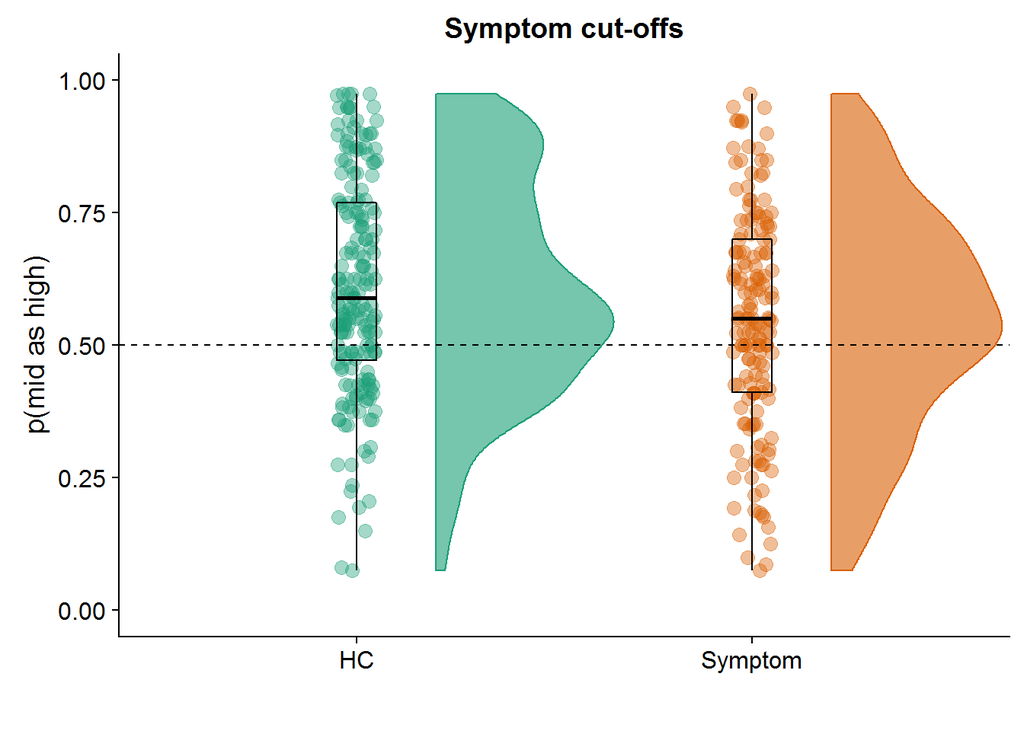

[output not shown]

```
## [1] "The number of controls is N = 198"
```

```
##
##  Two Sample t-test
##
## data:  Pmid by group
## t = 2.766, df = 349, p-value = 0.005976
## alternative hypothesis: true difference in means is not equal to 0
## 95 percent confidence interval:
##  0.01762747 0.10438403
## sample estimates:
##      mean in group HC mean in group Symptom
##             0.6087543             0.5477486
```

```
## [1] "The effect size of the Human group difference on p(mid as high) is d= 0.3"
```

```
##
##  Two Sample t-test
##
## data:  driftrate by group
## t = 2.78, df = 349, p-value = 0.005731
## alternative hypothesis: true difference in means is not equal to 0
## 95 percent confidence interval:
##  0.001015933 0.005930341
## sample estimates:
##      mean in group HC mean in group Symptom
##           0.006236747           0.002763610
```

```
## [1] "The effect size of the Human group difference on driftrate is d= 0.3"
```

### II) Latent mixture modelling (data-driven)

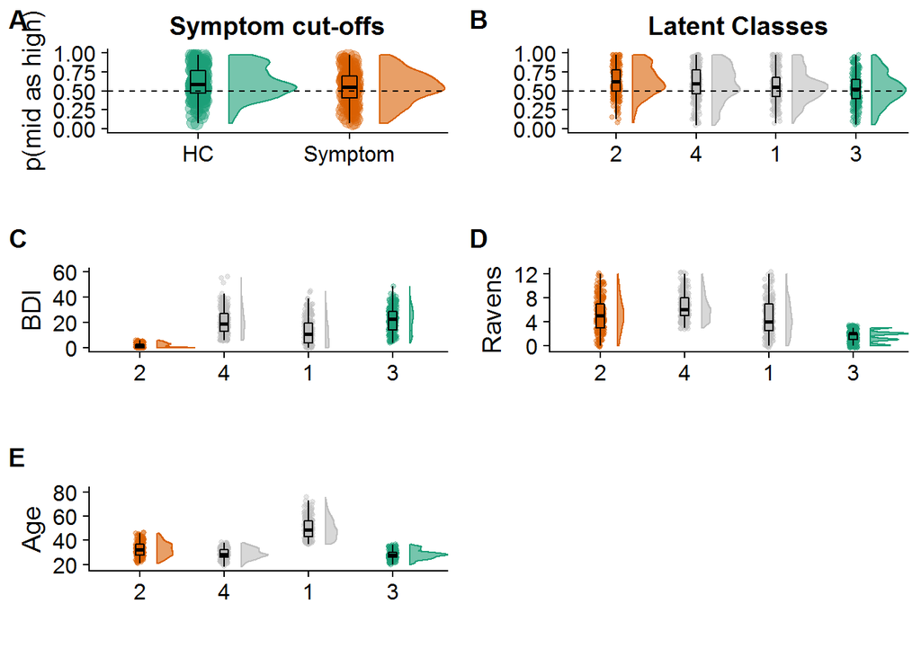

```
## ----------------------------------------------------
## Gaussian finite mixture model fitted by EM algorithm
## ----------------------------------------------------
##
## Mclust VVI (diagonal, varying volume and shape) model with 4 components:
##
##  log-likelihood   n df       BIC       ICL
##        -9629.49 994 27 -19445.33 -19841.74
##
## Clustering table:
##   1   2   3   4
## 219 233 266 276
```

```
##
##  Two Sample t-test
##
## data:  Pmid by group
## t = -5.8731, df = 497, p-value = 7.836e-09
## alternative hypothesis: true difference in means is not equal to 0
## 95 percent confidence interval:
##  -0.13813301 -0.06887991
## sample estimates:
##      mean in group HC mean in group Symptom
##             0.5310236             0.6345301
```

```
## [1] "The effect size of the Human group difference on driftrate is d= 0.53"
```

```
##
##  Two Sample t-test
##
## data:  BDI by group
## t = 32.016, df = 497, p-value < 2.2e-16
## alternative hypothesis: true difference in means is not equal to 0
## 95 percent confidence interval:
##  19.31422 21.83977
## sample estimates:
##      mean in group HC mean in group Symptom
##             22.259398              1.682403
```

```
## [1] "The effect size of the Human group difference is d= 2.87"
```

```
##
##  Two Sample t-test
##
## data:  Age by group
## t = -10.506, df = 497, p-value < 2.2e-16
## alternative hypothesis: true difference in means is not equal to 0
## 95 percent confidence interval:
##  -5.246439 -3.593246
## sample estimates:
##      mean in group HC mean in group Symptom
##              28.20677              32.62661
```

```
##
##  Two Sample t-test
##
## data:  Ravens by group
## t = -20.409, df = 497, p-value < 2.2e-16
## alternative hypothesis: true difference in means is not equal to 0
## 95 percent confidence interval:
##  -4.137983 -3.411244
## sample estimates:
##      mean in group HC mean in group Symptom
##              1.560150              5.334764
```

### Exploratory Factor Analysis of questionnaires

The simple regression above, however, collapses across the individual responses to the different items on the questionnaires and just uses summary scores. However, it may be that there is a simpler underlying structure to the data. For instance BDI and STAI are often highly correlated - so may actually be measuring the same latent construct. In this next section (inspired by Gillan et al 2016) we first run an exploratory factor analysis on the individual items from the questionnaires in an attempt to reduce the amount of latent variables.

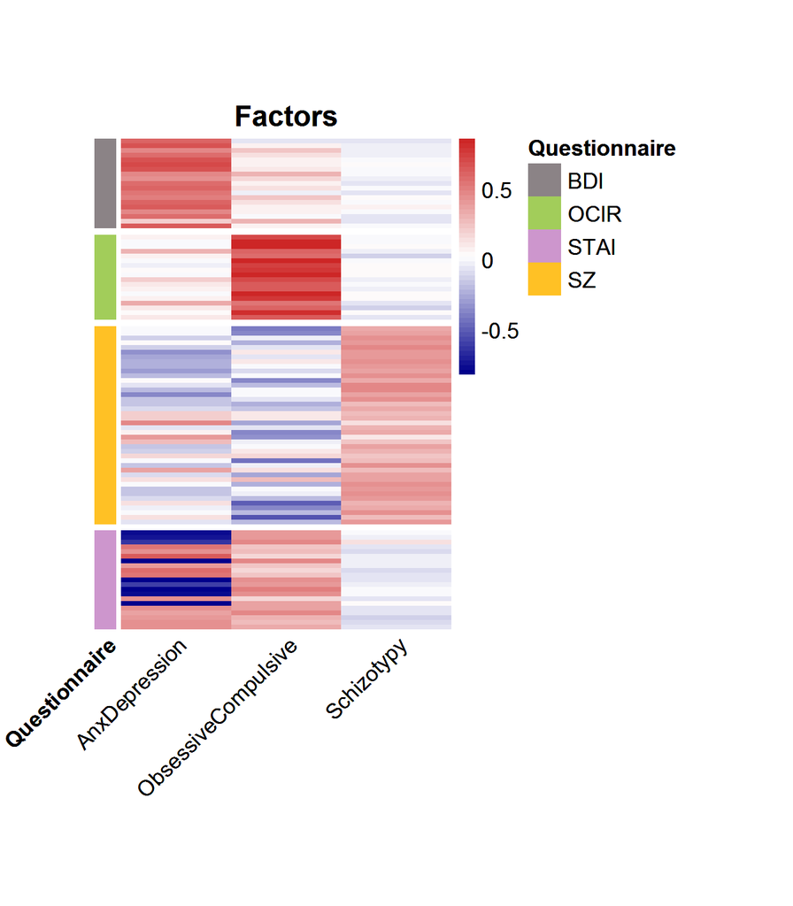

```r
###EFA

#Determine facrors using Cattell-Nelson-Gorsuch CNG Indices (claire's approach)
determinefactors <- nCng(combineditemdata[44:143], cor=TRUE, model="factors")
#Do an EFA using N factors from CNG
efaQaires <- fa(combineditemdata[44:143], nfact = determinefactors$nFactors, rotate = "geominQ", fm = "ml")

efaQaires.loadmat <- zapsmall(matrix(round(efaQaires$loadings, 2), nrow = 100, ncol = 3))
rownames(efaQaires.loadmat) <- names(combineditemdata[44:143])

#heatmap
efaQairesdataf <- data.frame(efaQaires.loadmat)
row.names(efaQairesdataf) <- gsub("_quantised", "", row.names(efaQairesdataf))
names(efaQairesdataf)<-c("AnxDepression","ObsessiveCompulsive","Schizotypy")
annotation <- substr(row.names(efaQairesdataf), start=1, stop=3)
annotationdf <- data.frame(Questionnaire = annotation)
levels(annotationdf$Questionnaire) <- c('BDI', 'OCIR', 'STAI', 'SZ')
rownames(annotationdf) <- rownames(efaQairesdataf)
countqs <- summary(annotationdf$Questionnaire)
qbreaks <- c(countqs[1], (countqs[1]+countqs[2]), (countqs[1]+countqs[2]+countqs[4]) )
ancol = list(Questionnaire =c(BDI ="lavenderblush4", OCIR ="darkolivegreen3", STAI ="plum3",SZ ="goldenrod1"))

heatmapplot <- pheatmap(
  mat               = efaQairesdataf,
  border_color      = NA,
  color             = colorRampPalette(c("darkblue", "white", "firebrick3"))(50),
  cellwidth         = 70,
  cellheight        = 3,
  show_colnames     = TRUE,
  show_rownames     = FALSE,
  drop_levels       = TRUE,
  fontsize          = 14,
  main              = "Factors",
  treeheight_row    = 0,
  treeheight_col    = 0,
  cluster_rows      = FALSE,
  annotation_row    = annotationdf,
  annotation_colors = ancol,
  angle_col         = 45,
  gaps_row          = qbreaks,
  gaps_col          = c(1,2),
  width             = 20,
    height            = 20
)


heatmapplot
```

#### Interpretation

We Identify 3 latent factors using Cattell-Nelson-Gorsuch Indices (as in Gillan et al.). One factor we name “AnxDepression” as it maps closely onto the BDI and STAI , “ObsessiveCompulsive” which is a mix of the OCIR and STAI (and not Schizotypy), and “Schizotypy” which loads positively almost exclusively on the Schizotypy questionnaire.

### Exploratory Structural Equation Model using latent factors

We can now use these factor loadings in an Exploratory Structural Equation Model (ESEM) and run the same regression as above but instead of feeding in the summary questionnaire scores, we can create a latent variable that represents each factor. Of note we use the ‘Robust maximum likelihood’ (MLR) estimator as it is robust to non-normality and the individual items for the questionnaires are not continuous.

```r
##ESEM which mimics regression - this takes the loadings from the EFA and uses them to weight the relationship between each questionnaire item and the three latent factors
terms <- vector()
for (i in 1:3) {
  terms[i] <-
    paste0("F",i,"=~ ", paste0(c(efaQaires.loadmat[,i]), "*", names(efaQaires.loadmat[,1]), collapse = "+"))
}

efaQaires.esem <- paste(terms, collapse = "\n")
##adding the regression and covariances to match the original regression analysis
terms[4] <- "propmedhigh ~ spreadsheet + Ravens + Age + GenderMF + F1 + F2 + F3"
##adding residual correlations
terms[5] <- "spreadsheet ~~ Ravens + Age + GenderMF + F1 + F2 + F3"
terms[6] <- "Ravens ~~ Age  + GenderMF + F1 + F2 + F3"
terms[7] <- "Age ~~  GenderMF + F1 + F2 + F3"
terms[8] <- "GenderMF ~~ F1 + F2 + F3"
terms[9] <- "F1 ~~ F2 + F3"
terms[10] <- "F2 ~~ F3"

semFactorsMatch <- paste(terms, collapse = "\n")

#Fit the model (this takes a while!)
fititem.factors <- sem(semFactorsMatch, data=combineditemdata, meanstructure=TRUE,  estimator = "MLR")

#This plots loads of fit indices, but we are mostly intersted in the regression
summary(fititem.factors, standardized=TRUE, rsquare=F, fit.measures=F)
```

```
## lavaan 0.6-3 ended normally after 267 iterations
##
##   Optimization method                           NLMINB
##   Number of free parameters                        241
##
##                                                   Used       Total
##   Number of observations                           990        1066
##
##   Estimator                                         ML      Robust
##   Model Fit Test Statistic                   19555.630   17207.926
##   Degrees of freedom                              5429        5429
##   P-value (Chi-square)                           0.000       0.000
##   Scaling correction factor                                  1.136
##     for the Yuan-Bentler correction (Mplus variant)
##
## Parameter Estimates:
##
##   Information                                 Observed
##   Observed information based on                Hessian
##   Standard Errors                   Robust.huber.white
##
## Latent Variables:
##                    Estimate  Std.Err  z-value  P(>|z|)   Std.lv  Std.all
##   F1 =~
##     BDI_Attrctv_qn    0.620                               0.540    0.595
##     BDI_Blam_qntsd    0.680                               0.592    0.677
##     BDI_Cry_quntsd    0.470                               0.409    0.465
##     BDI_Dcsns_qnts    0.590                               0.513    0.587
##     BDI_Dsppntmnt_    0.690                               0.600    0.682
##     BDI_Falr_qntsd    0.710                               0.618    0.684
##     BDI_Futr_qntsd    0.670                               0.583    0.658
##     BDI_Glty_qntsd    0.490                               0.426    0.481
##     BDI_Hlth_qntsd    0.430                               0.374    0.463
##     BDI_Intrs_I_P_    0.590                               0.513    0.584
##     BDI_Irrttd_qnt    0.600                               0.522    0.588
##     BDI_Libd_qntsd    0.540                               0.470    0.540
##     BDI_Pnshd_qnts    0.500                               0.435    0.467
##     BDI_Sad_quntsd    0.620                               0.540    0.647
##     BDI_Stsfctn_qn    0.640                               0.557    0.606
##     BDI_Slep_qntsd    0.480                               0.418    0.469
```

[output cut: 545 more lines]

```
##    .STAI2_SlfCnfd_    0.738    0.031   23.624    0.000    0.738    0.753
##    .STAI2_Stdy_qnt    0.365    0.020   18.468    0.000    0.365    0.493
##    .STAI2_Tnsn_qnt    0.450    0.022   20.459    0.000    0.450    0.522
##    .STAI2_Thghts_q    0.376    0.019   20.080    0.000    0.376    0.460
##    .STAI2_UnmprtT_    0.498    0.022   22.233    0.000    0.498    0.605
##    .STAI2_Wrry_qnt    0.568    0.025   23.055    0.000    0.568    0.645
##    .STAI_Anxs_qnts    0.533    0.027   20.016    0.000    0.533    0.577
##    .propmedhigh       0.041    0.002   24.811    0.000    0.041    0.947
##     spreadsheet       9.000    0.003 2595.746    0.000    9.000    1.000
##     Ravens            8.672    0.335   25.891    0.000    8.672    1.000
##     Age             104.591    6.150   17.008    0.000  104.591    1.000
##     GenderMF          0.242    0.003   86.073    0.000    0.242    1.000
##     F1                0.757    0.029   26.127    0.000    1.000    1.000
##     F2                0.912    0.036   25.590    0.000    1.000    1.000
##     F3                0.170    0.012   14.421    0.000    1.000    1.000
```

```r
ESEMfits <-data.frame(fitMeasures(fititem.factors, c("bic","aic","rmsea","rmsea.ci.lower", "rmsea.ci.upper")))
names(ESEMfits) <- "p(mid as high)"
rownames(ESEMfits) <- c("BIC", "AIC", "RMSEA", "RMSEA CI-", "RMSEA CI+")

kable(t(ESEMfits), digits = 3)
```

|  | BIC | AIC | RMSEA | RMSEA CI- | RMSEA CI+ |
| --- | --- | --- | --- | --- | --- |
| p(mid as high) | 199655.2 | 198474.8 | 0.051 | 0.05 | 0.052 |

#### Interpretation

In this ESEM we show that the AnxDepression factor (F1) alone significantly influences task performance. Zooming out, both the simple regression and the ESEM agree that of mental health-relevant symptoms, task performance is driven by symptoms of mood and anxiety disorders and not OCD or Psychosis symptoms. This suggests that our original clinical study in mood and anxiety disorders did not reflect a generic pathology, but rather that effects may be selective to the mood and anxiety symptom group that we originally tested. This also suggests that we must also control for age and IQ if we ever want to use this to inform clinical decision-making.